# Academic Writing Feature in Quarto

Part of In-Depth Quarto Authoring Workshop

Author

Jae Jung

Published

February 18, 2025

# 1 Features useful for professors

## 1.1 Topics to cover:

1. Citations
2. Footnote
3. References
4. Figure
5. Cross-referencing
6. Inline coding
7. Error: true/false

# 2 Sample Quarto Document

## 2.1 Quarto

## 2.2 Running Code

```
[1] 4
```

# 3 Exploring Data

````markdown
```{r}
#| label: tbl-mpg
#| tbl-cap: Data Showing mpg related data for automobilies
#| tbl-cap-location: top
library(tidyverse)
library(DT)
mpg |>
  datatable()
```
````

Table 1: Data Showing mpg related data for automobilies

|  | manufacturer | model | displ | year | cyl | trans | drv | cty | hwy | fl | class |
| --- | --- | --- | --- | --- | --- | --- | --- | --- | --- | --- | --- |
| 1 | audi | a4 | 1.8 | 1999 | 4 | auto(l5) | f | 18 | 29 | p | compact |
| 2 | audi | a4 | 1.8 | 1999 | 4 | manual(m5) | f | 21 | 29 | p | compact |
| 3 | audi | a4 | 2 | 2008 | 4 | manual(m6) | f | 20 | 31 | p | compact |
| 4 | audi | a4 | 2 | 2008 | 4 | auto(av) | f | 21 | 30 | p | compact |
| 5 | audi | a4 | 2.8 | 1999 | 6 | auto(l5) | f | 16 | 26 | p | compact |
| 6 | audi | a4 | 2.8 | 1999 | 6 | manual(m5) | f | 18 | 26 | p | compact |
| 7 | audi | a4 | 3.1 | 2008 | 6 | auto(av) | f | 18 | 27 | p | compact |
| 8 | audi | a4 quattro | 1.8 | 1999 | 4 | manual(m5) | 4 | 18 | 26 | p | compact |
| 9 | audi | a4 quattro | 1.8 | 1999 | 4 | auto(l5) | 4 | 16 | 25 | p | compact |
| 10 | audi | a4 quattro | 2 | 2008 | 4 | manual(m6) | 4 | 20 | 28 | p | compact |

[output cut: 224 more lines]

**Summary of Data**

Table 1 shows the interesting data for car-markers. There are 234 cars in the data.

## 3.1 How to Complete Rendering Quarto Files in the Face of an Error

```r
xmpg |>
  datatable()
```

```
Error: object 'xmpg' not found
```

**Warning**

There is an error in the file name, `xmpg`. The correct name should be `mpg`. When you cannot fix the error, rendering will stop. If you want to complete the rendering despite an error somewhere in the quarto file, you can add `error: true` to the `YAML` header. See the yaml header under `execute`section.

# 4 Pictures and Cross-Referencing

[figure not shown]

Figure 1: Graduates cellebrating

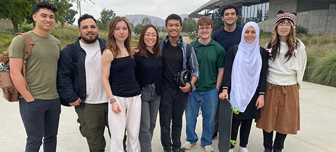

Figure 2: Belonging

Some college degrees hang on a wall. Get on that also paves the way to a brighter financial future (Figure 1).

Be inspired every day, inside and outside the classroom, by a diverse, supportive and creative community that will help you discover who you are and what you’re capable of (Figure 2).

# 5 Resources

- In-depth Quarto Authoring Workshop GitHub repo: https://github.com/CCIDM/in-depth-quarto-authoring

## References

Erickson, Richard A., Althea A. Archer, and Michael N. Fienen. 2024. “A Reproducible Manuscript Workflow With a Quarto Template.” *Journal of Fish and Wildlife Management* 15 (1): 251–58. https://doi.org/10.3996/jfwm-24-003.

Rönkkö, Mikko, and Eunseong Cho. 2022. “An Updated Guideline for Assessing Discriminant Validity.” *Organizational Research Methods* 25 (1): 6–14. https://doi.org/10.1177/1094428120968614.

## Footnotes

[^1]: This is just one of many articles about reproducible report.
[^2]: To add a code chunk, press control and “/” simultaneously.